# Project: No-show appointments

- Introduction
- Data Wrangling
- Exploratory Data Analysis
- Conclusions

## Introduction

### Dataset Description

> This dataset collects information from 100k medical appointments in Brazil and is focused on the question of whether or not patients show up for their appointment. A number of characteristics about the patient are included in each row.

## columns:

#### -Neighbourhood: indicates the location of the hospital.

#### -Scholarship: indicates whether or not the patient is enrolled in Brasilian welfare program Bolsa Família and it contains two values: 0 refers to be not enrolled and 1 refers to be enrolled.

#### -Hipertension: indicates whether or not the patient has high blood pressure.

#### -Diabetes: indicates whether or not the patient has Diabetes mellitus (is a chronic disease that impairs blood sugar regulation in the body) and it contains two values: 0 refers to not sick and 1 refers to sick.

#### -Alcoholism : indicates whether or not the patient is an addiction to drinking alcohol and it contains two values: 0 refers to not sick and 1 refers to sick.

#### -Handicap: indicates whether or not the patient has physical disability and it contains two values: 0 refers to not sick and 1 refers to sick.

#### -SMS_received: indicates whether or not the patient received message SMS and it contains two values: 0 refers to not sick and 1 refers to sick.

#### -No-show: it says ‘No’ if the patient showed up to their appointment, and ‘Yes’ if they did not show up.

### Question(s) for Analysis

#### 1)-Is there a relationship between No-show and Gender?

#### 2)-Is there a relationship between No-show and the age of patient?

#### 3)-Is there a relationship between No-show and location of the hospital?

#### 4)-Is there a relationship between No-show and whether patient is enrolled in Brasilian welfare program Bolsa Família?

#### 5)-Is there a relationship between No-show and whether the patient has Hypertension?

#### 6)-Is there a relationship between No-show and whether the patient is Diabetic?

#### 7)-Is there a relationship between No-show and whether the patient has Alcoholism?

#### 8)-Is there a relationship between No-show and whether the patient has Handicap?

#### 9)-Is there a relationship between No-show and whether the patient received SMS?

#### 10)-Is there a relationship between No-show and days of week?

#### 11)-Is there a relationship between No-show and the length of time between the day of booking and the day of the appointment?

#### 12)-What factors are important for us to know in order to predict if a patient will show up for their scheduled appointment?

```python
import numpy as np
import pandas as pd
import matplotlib.pyplot as plt
import seaborn as sns
plt.style.use('seaborn')
% matplotlib inline
```

## Data Wrangling

```python
# Loads the data and prints out a few lines. Performs operations to inspect data
#   types and looks for instances of missing or possibly errant data.
df = pd.read_csv('./Database_No_show_appointments/noshowappointments-kagglev2-may-2016.csv')
df.head()
```

|  | PatientId | AppointmentID | Gender | ScheduledDay | AppointmentDay | Age | Neighbourhood | Scholarship | Hipertension | Diabetes | Alcoholism | Handcap | SMS_received | No-show |
| --- | --- | --- | --- | --- | --- | --- | --- | --- | --- | --- | --- | --- | --- | --- |
| 0 | 2.987250e+13 | 5642903 | F | 2016-04-29T18:38:08Z | 2016-04-29T00:00:00Z | 62 | JARDIM DA PENHA | 0 | 1 | 0 | 0 | 0 | 0 | No |
| 1 | 5.589978e+14 | 5642503 | M | 2016-04-29T16:08:27Z | 2016-04-29T00:00:00Z | 56 | JARDIM DA PENHA | 0 | 0 | 0 | 0 | 0 | 0 | No |
| 2 | 4.262962e+12 | 5642549 | F | 2016-04-29T16:19:04Z | 2016-04-29T00:00:00Z | 62 | MATA DA PRAIA | 0 | 0 | 0 | 0 | 0 | 0 | No |
| 3 | 8.679512e+11 | 5642828 | F | 2016-04-29T17:29:31Z | 2016-04-29T00:00:00Z | 8 | PONTAL DE CAMBURI | 0 | 0 | 0 | 0 | 0 | 0 | No |
| 4 | 8.841186e+12 | 5642494 | F | 2016-04-29T16:07:23Z | 2016-04-29T00:00:00Z | 56 | JARDIM DA PENHA | 0 | 1 | 1 | 0 | 0 | 0 | No |

```python
df.describe()
```

|  | PatientId | AppointmentID | Age | Scholarship | Hipertension | Diabetes | Alcoholism | Handcap | SMS_received |
| --- | --- | --- | --- | --- | --- | --- | --- | --- | --- |
| count | 1.105270e+05 | 1.105270e+05 | 110527.000000 | 110527.000000 | 110527.000000 | 110527.000000 | 110527.000000 | 110527.000000 | 110527.000000 |
| mean | 1.474963e+14 | 5.675305e+06 | 37.088874 | 0.098266 | 0.197246 | 0.071865 | 0.030400 | 0.022248 | 0.321026 |
| std | 2.560949e+14 | 7.129575e+04 | 23.110205 | 0.297675 | 0.397921 | 0.258265 | 0.171686 | 0.161543 | 0.466873 |
| min | 3.921784e+04 | 5.030230e+06 | -1.000000 | 0.000000 | 0.000000 | 0.000000 | 0.000000 | 0.000000 | 0.000000 |
| 25% | 4.172614e+12 | 5.640286e+06 | 18.000000 | 0.000000 | 0.000000 | 0.000000 | 0.000000 | 0.000000 | 0.000000 |
| 50% | 3.173184e+13 | 5.680573e+06 | 37.000000 | 0.000000 | 0.000000 | 0.000000 | 0.000000 | 0.000000 | 0.000000 |
| 75% | 9.439172e+13 | 5.725524e+06 | 55.000000 | 0.000000 | 0.000000 | 0.000000 | 0.000000 | 0.000000 | 1.000000 |
| max | 9.999816e+14 | 5.790484e+06 | 115.000000 | 1.000000 | 1.000000 | 1.000000 | 1.000000 | 4.000000 | 1.000000 |

```python
df.info()
```

```
<class 'pandas.core.frame.DataFrame'>
RangeIndex: 110527 entries, 0 to 110526
Data columns (total 14 columns):
PatientId         110527 non-null float64
AppointmentID     110527 non-null int64
Gender            110527 non-null object
ScheduledDay      110527 non-null object
AppointmentDay    110527 non-null object
Age               110527 non-null int64
Neighbourhood     110527 non-null object
Scholarship       110527 non-null int64
Hipertension      110527 non-null int64
Diabetes          110527 non-null int64
Alcoholism        110527 non-null int64
Handcap           110527 non-null int64
SMS_received      110527 non-null int64
No-show           110527 non-null object
dtypes: float64(1), int64(8), object(5)
memory usage: 11.8+ MB
```

```python
df.nunique()
```

```
PatientId          62299
AppointmentID     110527
Gender                 2
ScheduledDay      103549
AppointmentDay        27
Age                  104
Neighbourhood         81
Scholarship            2
Hipertension           2
Diabetes               2
Alcoholism             2
Handcap                5
SMS_received           2
No-show                2
dtype: int64
```

### Data Cleaning

```python
# renames the columns having wrong spelling.
df.rename(columns={'Hipertension':'Hypertension','Handcap':'Handicap'},inplace=True)
```

```python
# drops some columns that we don't need in analysis like PatientId and AppointmentID.
df.drop(['PatientId','AppointmentID'],axis=1,inplace=True)
```

```python
df.query('Age <0')
```

|  | Gender | ScheduledDay | AppointmentDay | Age | Neighbourhood | Scholarship | Hypertension | Diabetes | Alcoholism | Handicap | SMS_received | No-show |
| --- | --- | --- | --- | --- | --- | --- | --- | --- | --- | --- | --- | --- |
| 99832 | F | 2016-06-06T08:58:13Z | 2016-06-06T00:00:00Z | -1 | ROMÃO | 0 | 0 | 0 | 0 | 0 | 0 | No |

```python
# if the age of any patient is less than 0 we will drop it
df.drop(df.query('Age <0').index,inplace=True)
df.Age.describe()
```

```
count    110526.000000
mean         37.089219
std          23.110026
min           0.000000
25%          18.000000
50%          37.000000
75%          55.000000
max         115.000000
Name: Age, dtype: float64
```

```python
# divides the ages to four periods between [0,18],[19,37],[38,55],and[56,115]
df['age_period'] = pd.cut(df['Age'], [-1, 18, 37, 55, 115],labels=['[0,18]', '[19,37]', '[38,55]', '[56,115]'])
```

```python
df.query('Handicap>1')
```

|  | Gender | ScheduledDay | AppointmentDay | Age | Neighbourhood | Scholarship | Hypertension | Diabetes | Alcoholism | Handicap | SMS_received | No-show | age_period |
| --- | --- | --- | --- | --- | --- | --- | --- | --- | --- | --- | --- | --- | --- |
| 946 | M | 2016-04-14T09:26:08Z | 2016-04-29T00:00:00Z | 94 | BELA VISTA | 0 | 1 | 1 | 0 | 2 | 1 | No | [56,115] |
| 1665 | M | 2016-03-30T09:16:41Z | 2016-04-29T00:00:00Z | 64 | SANTA MARTHA | 0 | 1 | 0 | 1 | 2 | 1 | No | [56,115] |
| 1666 | M | 2016-03-30T09:16:41Z | 2016-04-29T00:00:00Z | 64 | SANTA MARTHA | 0 | 1 | 0 | 1 | 2 | 0 | No | [56,115] |
| 2071 | M | 2016-04-29T10:08:48Z | 2016-04-29T00:00:00Z | 64 | SANTA MARTHA | 0 | 1 | 0 | 1 | 2 | 0 | No | [56,115] |
| 2091 | F | 2016-04-29T08:13:59Z | 2016-04-29T00:00:00Z | 11 | ANDORINHAS | 0 | 0 | 0 | 0 | 2 | 0 | No | [0,18] |
| 2213 | F | 2016-04-29T11:22:50Z | 2016-04-29T00:00:00Z | 29 | VILA RUBIM | 0 | 0 | 0 | 0 | 2 | 0 | No | [19,37] |
| 2214 | M | 2016-04-29T11:22:20Z | 2016-04-29T00:00:00Z | 55 | DO QUADRO | 0 | 0 | 0 | 0 | 3 | 0 | No | [38,55] |
| 2673 | M | 2016-04-15T13:06:05Z | 2016-04-29T00:00:00Z | 17 | SANTA TEREZA | 0 | 0 | 0 | 0 | 2 | 1 | No | [0,18] |
| 5424 | M | 2016-05-02T13:24:36Z | 2016-05-04T00:00:00Z | 65 | SANTO ANDRÉ | 0 | 1 | 1 | 1 | 2 | 0 | Yes | [56,115] |
| 5467 | F | 2016-05-12T09:10:28Z | 2016-05-16T00:00:00Z | 10 | BENTO FERREIRA | 0 | 0 | 0 | 0 | 2 | 0 | No | [0,18] |
| 5475 | F | 2016-05-12T09:10:50Z | 2016-05-16T00:00:00Z | 34 | JUCUTUQUARA | 0 | 0 | 0 | 0 | 2 | 0 | Yes | [19,37] |
| 5485 | F | 2016-05-05T10:23:26Z | 2016-05-09T00:00:00Z | 16 | SANTA TEREZA | 0 | 0 | 0 | 0 | 2 | 0 | No | [0,18] |
| 5510 | F | 2016-05-04T11:06:48Z | 2016-05-05T00:00:00Z | 42 | SÃO PEDRO | 0 | 1 | 0 | 0 | 2 | 0 | No | [38,55] |
| 6067 | F | 2016-05-17T07:41:55Z | 2016-05-19T00:00:00Z | 10 | RESISTÊNCIA | 0 | 0 | 0 | 0 | 2 | 0 | Yes | [0,18] |
| 6156 | F | 2016-05-13T07:39:38Z | 2016-05-17T00:00:00Z | 29 | SANTO ANTÔNIO | 0 | 0 | 0 | 0 | 2 | 0 | No | [19,37] |
| 6401 | F | 2016-05-11T07:32:16Z | 2016-05-13T00:00:00Z | 19 | VILA RUBIM | 0 | 0 | 0 | 0 | 2 | 0 | No | [19,37] |
| 11227 | M | 2016-04-15T08:49:43Z | 2016-05-19T00:00:00Z | 18 | RESISTÊNCIA | 0 | 0 | 0 | 0 | 2 | 0 | No | [0,18] |
| 11230 | M | 2016-03-18T15:02:00Z | 2016-05-19T00:00:00Z | 18 | RESISTÊNCIA | 0 | 0 | 0 | 0 | 2 | 0 | No | [0,18] |
| 14847 | M | 2016-04-05T09:04:49Z | 2016-05-05T00:00:00Z | 17 | SANTA TEREZA | 0 | 0 | 0 | 0 | 2 | 1 | No | [0,18] |
| 15839 | F | 2016-05-02T09:46:27Z | 2016-05-12T00:00:00Z | 52 | DE LOURDES | 0 | 1 | 0 | 0 | 2 | 1 | No | [38,55] |
| 15845 | F | 2016-05-02T09:46:40Z | 2016-05-12T00:00:00Z | 52 | DE LOURDES | 0 | 1 | 0 | 0 | 2 | 0 | No | [38,55] |
| 16632 | F | 2016-05-02T08:04:06Z | 2016-05-09T00:00:00Z | 32 | SANTA MARTHA | 0 | 0 | 0 | 0 | 2 | 0 | No | [19,37] |
| 16634 | F | 2016-04-27T12:03:16Z | 2016-05-02T00:00:00Z | 32 | SANTA MARTHA | 0 | 0 | 0 | 0 | 2 | 0 | Yes | [19,37] |
| 16635 | F | 2016-05-02T08:04:06Z | 2016-05-09T00:00:00Z | 32 | SANTA MARTHA | 0 | 0 | 0 | 0 | 2 | 0 | No | [19,37] |
| 16636 | F | 2016-04-27T12:01:01Z | 2016-05-02T00:00:00Z | 32 | SANTA MARTHA | 0 | 0 | 0 | 0 | 2 | 0 | Yes | [19,37] |
| 17862 | F | 2016-05-06T07:59:24Z | 2016-05-06T00:00:00Z | 37 | SANTO ANDRÉ | 0 | 0 | 0 | 0 | 2 | 0 | No | [19,37] |
| 18241 | M | 2016-04-28T11:58:14Z | 2016-05-04T00:00:00Z | 4 | PRAIA DO SUÁ | 0 | 0 | 0 | 0 | 2 | 1 | No | [0,18] |
| 19264 | F | 2016-04-26T09:39:37Z | 2016-05-10T00:00:00Z | 89 | ILHA DO PRÍNCIPE | 0 | 1 | 0 | 0 | 2 | 1 | Yes | [56,115] |
| 19915 | M | 2016-04-27T08:25:25Z | 2016-05-11T00:00:00Z | 16 | BELA VISTA | 0 | 0 | 0 | 0 | 2 | 1 | No | [0,18] |
| 19981 | M | 2016-05-09T15:27:02Z | 2016-05-12T00:00:00Z | 89 | BELA VISTA | 0 | 1 | 1 | 0 | 2 | 0 | No | [56,115] |
| ... | ... | ... | ... | ... | ... | ... | ... | ... | ... | ... | ... | ... | ... |
| 96173 | M | 2016-05-10T10:57:48Z | 2016-06-07T00:00:00Z | 82 | MATA DA PRAIA | 0 | 1 | 0 | 0 | 2 | 0 | No | [56,115] |
| 96457 | M | 2016-06-06T15:02:34Z | 2016-06-07T00:00:00Z | 29 | JARDIM DA PENHA | 0 | 0 | 0 | 0 | 2 | 0 | No | [19,37] |
| 96831 | F | 2016-05-19T14:08:28Z | 2016-06-02T00:00:00Z | 97 | MARUÍPE | 0 | 1 | 0 | 0 | 2 | 0 | No | [56,115] |
| 97998 | F | 2016-06-02T09:21:08Z | 2016-06-02T00:00:00Z | 8 | TABUAZEIRO | 0 | 0 | 0 | 0 | 2 | 0 | No | [0,18] |
| 98045 | F | 2016-06-07T14:56:08Z | 2016-06-07T00:00:00Z | 52 | DE LOURDES | 0 | 1 | 0 | 0 | 2 | 0 | No | [38,55] |
| 98538 | M | 2016-06-01T15:11:25Z | 2016-06-03T00:00:00Z | 19 | SÃO PEDRO | 0 | 0 | 0 | 0 | 4 | 0 | No | [19,37] |
| 99455 | F | 2016-06-02T11:06:13Z | 2016-06-02T00:00:00Z | 40 | DO QUADRO | 0 | 0 | 0 | 0 | 2 | 0 | No | [38,55] |
| 100538 | M | 2016-06-07T09:27:29Z | 2016-06-07T00:00:00Z | 11 | GOIABEIRAS | 1 | 0 | 0 | 0 | 2 | 0 | No | [0,18] |
| 101074 | F | 2016-05-09T09:00:57Z | 2016-06-07T00:00:00Z | 33 | SANTA MARTHA | 0 | 0 | 0 | 0 | 2 | 0 | No | [19,37] |
| 101911 | M | 2016-06-07T11:10:08Z | 2016-06-07T00:00:00Z | 84 | RESISTÊNCIA | 0 | 1 | 0 | 0 | 2 | 0 | Yes | [56,115] |
| 101912 | M | 2016-06-07T11:09:45Z | 2016-06-07T00:00:00Z | 84 | RESISTÊNCIA | 0 | 1 | 0 | 0 | 2 | 0 | No | [56,115] |
| 101913 | M | 2016-06-07T11:10:22Z | 2016-06-07T00:00:00Z | 84 | RESISTÊNCIA | 0 | 1 | 0 | 0 | 2 | 0 | Yes | [56,115] |
| 101949 | M | 2016-06-06T15:14:05Z | 2016-06-08T00:00:00Z | 12 | ESTRELINHA | 0 | 0 | 0 | 0 | 2 | 0 | Yes | [0,18] |
| 102276 | M | 2016-06-06T14:02:28Z | 2016-06-06T00:00:00Z | 89 | BELA VISTA | 0 | 1 | 1 | 0 | 2 | 0 | No | [56,115] |
| 102360 | F | 2016-06-01T09:00:14Z | 2016-06-01T00:00:00Z | 44 | ROMÃO | 0 | 1 | 1 | 0 | 2 | 0 | No | [38,55] |
| 102955 | F | 2016-06-06T10:45:58Z | 2016-06-06T00:00:00Z | 15 | JOANA D´ARC | 1 | 0 | 0 | 0 | 2 | 0 | No | [0,18] |
| 104268 | F | 2016-05-13T15:01:17Z | 2016-06-02T00:00:00Z | 9 | ITARARÉ | 0 | 0 | 0 | 0 | 4 | 1 | Yes | [0,18] |
| 104927 | M | 2016-05-24T16:35:44Z | 2016-06-01T00:00:00Z | 70 | ANDORINHAS | 0 | 0 | 0 | 1 | 3 | 0 | No | [56,115] |
| 104931 | M | 2016-05-24T16:35:44Z | 2016-06-01T00:00:00Z | 70 | ANDORINHAS | 0 | 0 | 0 | 1 | 3 | 0 | No | [56,115] |
| 104932 | M | 2016-05-24T16:35:44Z | 2016-06-01T00:00:00Z | 70 | ANDORINHAS | 0 | 0 | 0 | 1 | 3 | 0 | No | [56,115] |
| 105008 | F | 2016-06-07T09:03:12Z | 2016-06-07T00:00:00Z | 37 | SANTO ANDRÉ | 0 | 0 | 0 | 0 | 2 | 0 | No | [19,37] |
| 105073 | F | 2016-05-16T07:20:46Z | 2016-06-01T00:00:00Z | 35 | BELA VISTA | 1 | 0 | 1 | 0 | 2 | 1 | No | [19,37] |
| 105322 | M | 2016-06-01T07:23:50Z | 2016-06-01T00:00:00Z | 6 | SANTA CLARA | 0 | 0 | 0 | 0 | 2 | 0 | No | [0,18] |
| 105753 | M | 2016-05-31T14:41:50Z | 2016-06-02T00:00:00Z | 32 | REDENÇÃO | 0 | 0 | 0 | 0 | 2 | 0 | No | [19,37] |
| 108335 | M | 2016-06-03T09:11:46Z | 2016-06-08T00:00:00Z | 45 | ROMÃO | 0 | 0 | 0 | 0 | 2 | 1 | No | [38,55] |
| 108376 | F | 2016-06-01T08:48:28Z | 2016-06-07T00:00:00Z | 44 | ROMÃO | 0 | 1 | 1 | 0 | 2 | 1 | No | [38,55] |
| 109484 | M | 2016-05-31T11:45:57Z | 2016-06-02T00:00:00Z | 64 | DA PENHA | 0 | 1 | 1 | 0 | 2 | 0 | No | [56,115] |
| 109733 | F | 2016-06-03T16:11:00Z | 2016-06-07T00:00:00Z | 34 | JUCUTUQUARA | 0 | 0 | 0 | 0 | 2 | 1 | No | [19,37] |
| 109975 | M | 2016-06-02T16:07:36Z | 2016-06-06T00:00:00Z | 39 | PRAIA DO SUÁ | 1 | 0 | 0 | 0 | 2 | 1 | No | [38,55] |
| 110107 | F | 2016-06-02T06:44:00Z | 2016-06-06T00:00:00Z | 44 | RESISTÊNCIA | 0 | 0 | 0 | 0 | 2 | 1 | No | [38,55] |

199 rows × 13 columns

```python
df['Handicap'].unique()
```

```
array([0, 1, 2, 3, 4])
```

```python
# the column 'Handicap' should have only values 0 or 1 which mean false or true
# and not contains the number of Handicap [2,3,4] for each patient
# so we will replace all incorrect values from column 'Handicap' [2,3,4]  by the value of 1
df['Handicap'].replace(to_replace =[2, 3,4], value =1,inplace=True)
df['Handicap'].describe()
```

```
count    110526.000000
mean          0.020276
std           0.140943
min           0.000000
25%           0.000000
50%           0.000000
75%           0.000000
max           1.000000
Name: Handicap, dtype: float64
```

```python
df['ScheduledDay'] = pd.to_datetime(df['ScheduledDay'])
df['AppointmentDay'] = pd.to_datetime(df['AppointmentDay'])
# we will find the difference between Scheduled Day and Appointment Day to knowif there is a relationship
# between No-show and the length of time between the day of booking and the day of the appointment
df['diff_day'] = ((df['AppointmentDay'] - df['ScheduledDay']).dt.days)+1
# we will find the day of the week for Appointment Days to know if there is a relationship
# between No-show and   days of the week
df['day_of_week']=df['AppointmentDay'].dt.day_name()
df.describe()
```

|  | Age | Scholarship | Hypertension | Diabetes | Alcoholism | Handicap | SMS_received | diff_day |
| --- | --- | --- | --- | --- | --- | --- | --- | --- |
| count | 110526.000000 | 110526.000000 | 110526.000000 | 110526.000000 | 110526.000000 | 110526.000000 | 110526.000000 | 110526.000000 |
| mean | 37.089219 | 0.098266 | 0.197248 | 0.071865 | 0.030400 | 0.020276 | 0.321029 | 10.183794 |
| std | 23.110026 | 0.297676 | 0.397923 | 0.258266 | 0.171686 | 0.140943 | 0.466874 | 15.255034 |
| min | 0.000000 | 0.000000 | 0.000000 | 0.000000 | 0.000000 | 0.000000 | 0.000000 | -6.000000 |
| 25% | 18.000000 | 0.000000 | 0.000000 | 0.000000 | 0.000000 | 0.000000 | 0.000000 | 0.000000 |
| 50% | 37.000000 | 0.000000 | 0.000000 | 0.000000 | 0.000000 | 0.000000 | 0.000000 | 4.000000 |
| 75% | 55.000000 | 0.000000 | 0.000000 | 0.000000 | 0.000000 | 0.000000 | 1.000000 | 15.000000 |
| max | 115.000000 | 1.000000 | 1.000000 | 1.000000 | 1.000000 | 1.000000 | 1.000000 | 179.000000 |

```python
df.query('diff_day<0')
```

|  | Gender | ScheduledDay | AppointmentDay | Age | Neighbourhood | Scholarship | Hypertension | Diabetes | Alcoholism | Handicap | SMS_received | No-show | age_period | diff_day | day_of_week |
| --- | --- | --- | --- | --- | --- | --- | --- | --- | --- | --- | --- | --- | --- | --- | --- |
| 27033 | M | 2016-05-10 10:51:53 | 2016-05-09 | 38 | RESISTÊNCIA | 0 | 0 | 0 | 0 | 1 | 0 | Yes | [38,55] | -1 | Monday |
| 55226 | F | 2016-05-18 14:50:41 | 2016-05-17 | 19 | SANTO ANTÔNIO | 0 | 0 | 0 | 0 | 1 | 0 | Yes | [19,37] | -1 | Tuesday |
| 64175 | F | 2016-05-05 13:43:58 | 2016-05-04 | 22 | CONSOLAÇÃO | 0 | 0 | 0 | 0 | 0 | 0 | Yes | [19,37] | -1 | Wednesday |
| 71533 | F | 2016-05-11 13:49:20 | 2016-05-05 | 81 | SANTO ANTÔNIO | 0 | 0 | 0 | 0 | 0 | 0 | Yes | [56,115] | -6 | Thursday |
| 72362 | M | 2016-05-04 06:50:57 | 2016-05-03 | 7 | TABUAZEIRO | 0 | 0 | 0 | 0 | 0 | 0 | Yes | [0,18] | -1 | Tuesday |

```python
# removes any errant values for the column of difference between Scheduled Day and Appointment Day
# if any difference between the two dates is less than '0'  we will drop it
df.drop(df.query('diff_day <0').index,inplace=True)
df.diff_day.describe()
```

```
count    110521.000000
mean         10.184345
std          15.255153
min           0.000000
25%           0.000000
50%           4.000000
75%          15.000000
max         179.000000
Name: diff_day, dtype: float64
```

```python
# divides the diff_day to four periods between [0,4],[5,15],[16,179]
df['diff_period'] = pd.cut(
    df['diff_day'], [-1, 0, 4, 15, 179], labels=['the same day', '[1,4]', '[5,15]', '[16,179]'])
```

[output not shown]

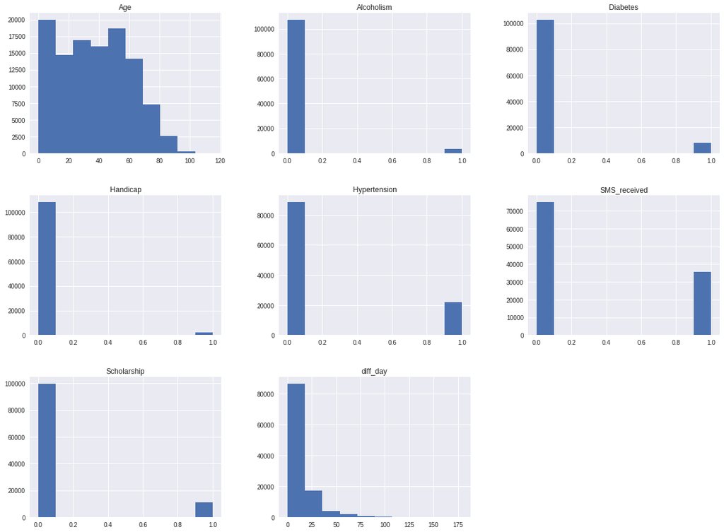

```python
df.hist(figsize=(20,15))
```

```python
df.info()
```

```
<class 'pandas.core.frame.DataFrame'>
Int64Index: 110521 entries, 0 to 110526
Data columns (total 16 columns):
Gender            110521 non-null object
ScheduledDay      110521 non-null datetime64[ns]
AppointmentDay    110521 non-null datetime64[ns]
Age               110521 non-null int64
Neighbourhood     110521 non-null object
Scholarship       110521 non-null int64
Hypertension      110521 non-null int64
Diabetes          110521 non-null int64
Alcoholism        110521 non-null int64
Handicap          110521 non-null int64
SMS_received      110521 non-null int64
No-show           110521 non-null object
age_period        110521 non-null category
diff_day          110521 non-null int64
day_of_week       110521 non-null object
diff_period       110521 non-null category
dtypes: category(2), datetime64[ns](2), int64(8), object(4)
memory usage: 12.9+ MB
```

```python
#we will divide the data to absentees and attendees to make it easy to know
#What factors are important for us in order to
#predict if a patient will show up for their scheduled appointment?
df_Absentees = df[df['No-show'] == 'Yes']
df_attendees = df[df['No-show'] == 'No']
```

```python
df_Absentees.describe()
```

|  | Age | Scholarship | Hypertension | Diabetes | Alcoholism | Handicap | SMS_received | diff_day |
| --- | --- | --- | --- | --- | --- | --- | --- | --- |
| count | 22314.000000 | 22314.000000 | 22314.000000 | 22314.000000 | 22314.000000 | 22314.000000 | 22314.000000 | 22314.000000 |
| mean | 34.317872 | 0.115533 | 0.169042 | 0.064085 | 0.030340 | 0.018150 | 0.438469 | 15.835484 |
| std | 21.965009 | 0.319671 | 0.374797 | 0.244910 | 0.171524 | 0.133497 | 0.496211 | 16.605600 |
| min | 0.000000 | 0.000000 | 0.000000 | 0.000000 | 0.000000 | 0.000000 | 0.000000 | 0.000000 |
| 25% | 16.000000 | 0.000000 | 0.000000 | 0.000000 | 0.000000 | 0.000000 | 0.000000 | 4.000000 |
| 50% | 33.000000 | 0.000000 | 0.000000 | 0.000000 | 0.000000 | 0.000000 | 0.000000 | 11.000000 |
| 75% | 51.000000 | 0.000000 | 0.000000 | 0.000000 | 0.000000 | 0.000000 | 1.000000 | 23.000000 |
| max | 115.000000 | 1.000000 | 1.000000 | 1.000000 | 1.000000 | 1.000000 | 1.000000 | 179.000000 |

```python
df_attendees.describe()
```

|  | Age | Scholarship | Hypertension | Diabetes | Alcoholism | Handicap | SMS_received | diff_day |
| --- | --- | --- | --- | --- | --- | --- | --- | --- |
| count | 88207.000000 | 88207.000000 | 88207.000000 | 88207.000000 | 88207.000000 | 88207.000000 | 88207.000000 | 88207.000000 |
| mean | 37.790504 | 0.093904 | 0.204394 | 0.073838 | 0.030417 | 0.020792 | 0.291337 | 8.754759 |
| std | 23.338645 | 0.291697 | 0.403261 | 0.261508 | 0.171733 | 0.142688 | 0.454381 | 14.550450 |
| min | 0.000000 | 0.000000 | 0.000000 | 0.000000 | 0.000000 | 0.000000 | 0.000000 | 0.000000 |
| 25% | 18.000000 | 0.000000 | 0.000000 | 0.000000 | 0.000000 | 0.000000 | 0.000000 | 0.000000 |
| 50% | 38.000000 | 0.000000 | 0.000000 | 0.000000 | 0.000000 | 0.000000 | 0.000000 | 2.000000 |
| 75% | 56.000000 | 0.000000 | 0.000000 | 0.000000 | 0.000000 | 0.000000 | 1.000000 | 12.000000 |
| max | 115.000000 | 1.000000 | 1.000000 | 1.000000 | 1.000000 | 1.000000 | 1.000000 | 179.000000 |

## Exploratory Data Analysis

### Is there a relationship between No-show and Gender?

```python
df['Gender'].value_counts().sort_values(ascending=False)
```

```
F    71836
M    38685
Name: Gender, dtype: int64
```

```
	Attendees
Gender
F    57245
M    30962
Name: No-show, dtype: int64
----------------------------------------
	Absentees
Gender
F    14591
M     7723
Name: No-show, dtype: int64
```

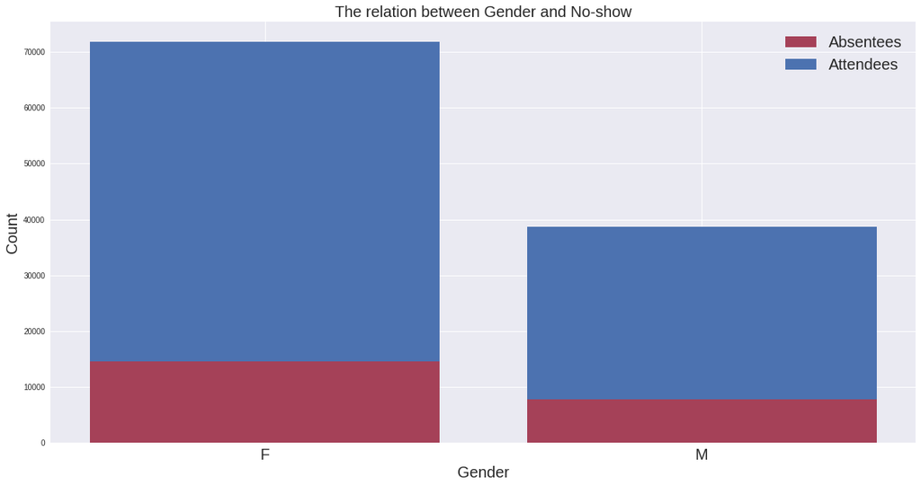

```python
Gender_Absentees = df_Absentees.groupby('Gender')['No-show'].count()
Gender_attendees = df_attendees.groupby('Gender')['No-show'].count()
print('\tAttendees')
print(Gender_attendees)
print('-'*40)
print('\tAbsentees')
print(Gender_Absentees)
plt.figure(figsize=(20, 10))
plt.bar(np.arange(len(Gender_Absentees)),
        Gender_Absentees, label='Absentees',color='#A54158')
plt.bar(np.arange(len(Gender_attendees)), Gender_attendees,
        label='Attendees',bottom=Gender_Absentees)
plt.xticks(np.arange(len(Gender_Absentees)),
           Gender_attendees.index, rotation=0, fontsize=20)
def design(x,y):
    '''axes design'''
    plt.title(f'The relation between {x} and No-show', fontsize=20)
    plt.xlabel(x, fontsize=20)
    plt.ylabel(y, fontsize=20)
    plt.legend(prop={'size': 20})
    plt.show()
design('Gender','Count')
```

#### to make a clear comparison to find out the attendance and absence rate for each gender let's divide each count by the total count for Absentees and Attendees to use proportions instead

```
----------------------------------------------------------------------------------------------------
	Attendees Proportion
Gender
M    0.800362
F    0.796885
Name: No-show, dtype: float64
----------------------------------------
	Absentees Proportion
Gender
M    0.199638
F    0.203115
Name: No-show, dtype: float64
```

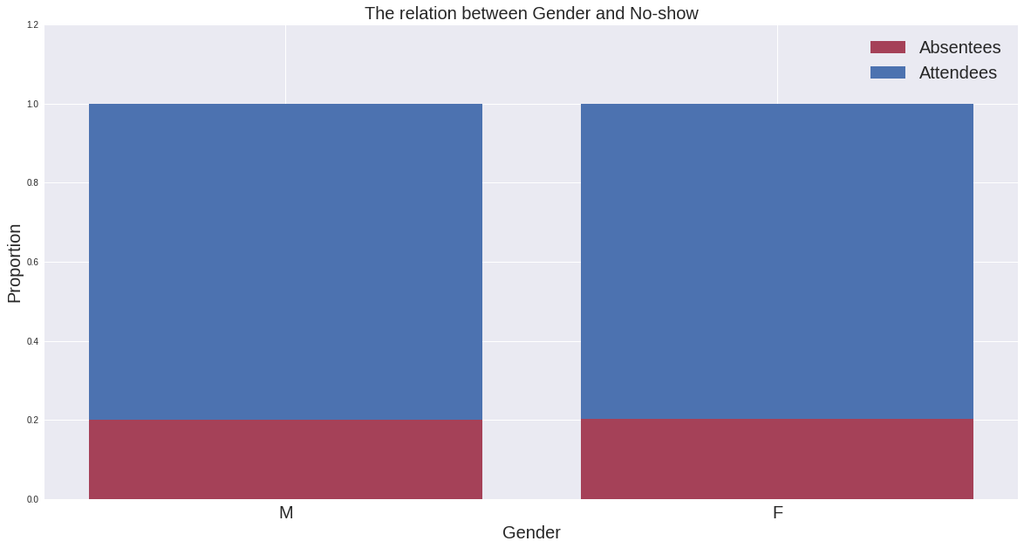

```python
total_Gender = df.groupby('Gender')['No-show'].count()
# calculate propotion for Absentees and attendees
p_Absentees_Gender = ((Gender_Absentees/total_Gender)
                ).fillna(0).sort_values(ascending=True)
p_attendees_Gender = ((Gender_attendees/total_Gender)
               ).fillna(0).sort_values(ascending=False)
print('-'*100)
print('\tAttendees Proportion')
print(p_attendees_Gender)
print('-'*40)
print('\tAbsentees Proportion')
print(p_Absentees_Gender)
plt.figure(figsize=(20, 10))
plt.bar(np.arange(len(p_Absentees_Gender)),
        p_Absentees_Gender, label='Absentees',color='#A54158')
plt.bar(np.arange(len(p_attendees_Gender)), p_attendees_Gender,
        label='Attendees', bottom=p_Absentees_Gender)
plt.xticks(np.arange(len(total_Gender)),
           p_attendees_Gender.index, rotation=0, fontsize=20)
plt.ylim(0,1.2)
design('Gender','Proportion')
```

the attendance and absence rate for each gender is convergent,the gender don't have any effect on it

### Is there a relationship between No-show and the age of patient?

```python
# divides the ages to four periods between [0,18],[19,37],[38,55],and[56,115]
df['age_period'].value_counts().sort_values(ascending=False)
```

```
[0,18]      28865
[56,115]    27503
[19,37]     27248
[38,55]     26905
Name: age_period, dtype: int64
```

```
	Attendees
age_period
[0,18]      22519
[19,37]     20836
[38,55]     21651
[56,115]    23201
Name: No-show, dtype: int64
----------------------------------------
	Absentees
age_period
[0,18]      6346
[19,37]     6412
[38,55]     5254
[56,115]    4302
Name: No-show, dtype: int64
```

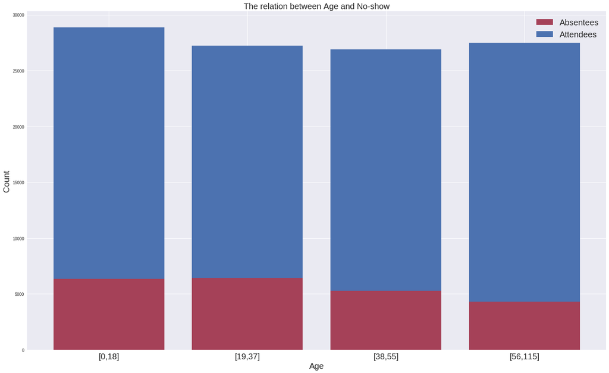

```python
age_period_Absentees = df_Absentees.groupby('age_period')['No-show'].count()
age_period_attendees = df_attendees.groupby('age_period')['No-show'].count()
print('\tAttendees')
print(age_period_attendees)
print('-'*40)
print('\tAbsentees')
print(age_period_Absentees)
plt.figure(figsize=(25, 15))
plt.bar(np.arange(len(age_period_Absentees)),
        age_period_Absentees, label='Absentees', color='#A54158')
plt.bar(np.arange(len(age_period_attendees)), age_period_attendees,
        label='Attendees', bottom=age_period_Absentees)
plt.xticks(np.arange(len(age_period_Absentees)),
           age_period_attendees.index, rotation=0, fontsize=20)
design('Age','Count')
```

#### to make a clear comparison to find out the attendance and absence rate for each age let's divide each count by the total count for Absences and Attendees to use proportions instead

```
----------------------------------------------------------------------------------------------------
	Attendees Proportion
age_period
[0,18]      0.780149
[19,37]     0.764680
[38,55]     0.804720
[56,115]    0.843581
Name: No-show, dtype: float64
----------------------------------------
	Absentees Proportion
age_period
[0,18]      0.219851
[19,37]     0.235320
[38,55]     0.195280
[56,115]    0.156419
Name: No-show, dtype: float64
```

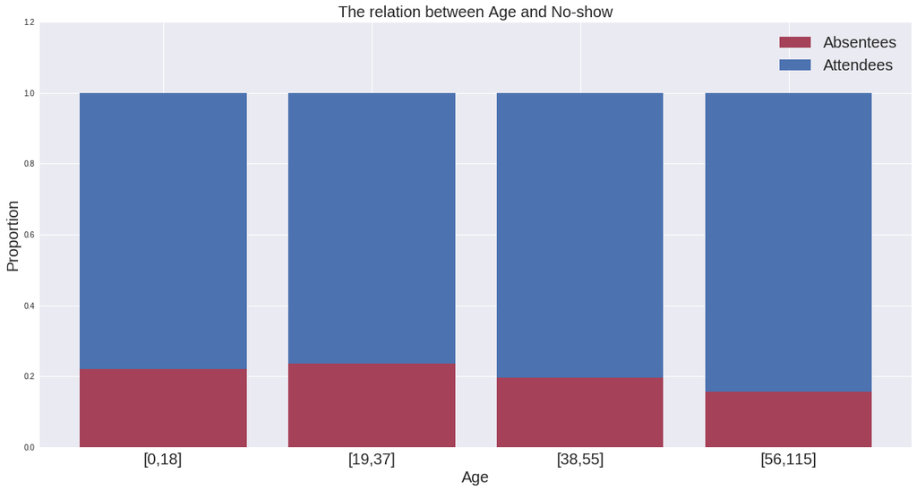

```python
age_period_Absentees = df_Absentees.groupby('age_period')['No-show'].count()
age_period_attendees = df_attendees.groupby('age_period')['No-show'].count()
total_age_period = df.groupby('age_period')['No-show'].count()
p_Absentees_age_period = ((age_period_Absentees/total_age_period)
                          ).fillna(0)
p_attendees_age_period = ((age_period_attendees/total_age_period)
                          ).fillna(0)
print('-'*100)
print('\tAttendees Proportion')
print(p_attendees_age_period)
print('-'*40)
print('\tAbsentees Proportion')
print(p_Absentees_age_period)
plt.figure(figsize=(20, 10))
plt.bar(np.arange(len(p_Absentees_age_period)),
        p_Absentees_age_period, label='Absentees', color='#A54158')
plt.bar(np.arange(len(p_attendees_age_period)), p_attendees_age_period,
        label='Attendees', bottom=p_Absentees_age_period)
plt.xticks(np.arange(len(total_age_period)),
           p_attendees_age_period.index, rotation=0, fontsize=20)
plt.ylim(0, 1.2)
design('Age','Proportion')
```

The No-show rate rises between 1 and 18 and reaches its highest level between 19 and 37, but it decreases between 38 and 55 to reach its lowest level between 56 and 115

### Is there a relationship between No-show and location of the hospital?

```python
df['Neighbourhood'].value_counts().sort_values(ascending=False)
```

```
JARDIM CAMBURI                 7717
MARIA ORTIZ                    5805
RESISTÊNCIA                    4430
JARDIM DA PENHA                3877
ITARARÉ                        3514
CENTRO                         3334
SANTA MARTHA                   3131
TABUAZEIRO                     3131
JESUS DE NAZARETH              2853
BONFIM                         2773
SANTO ANTÔNIO                  2744
SANTO ANDRÉ                    2571
CARATOÍRA                      2565
JABOUR                         2509
SÃO PEDRO                      2448
ILHA DO PRÍNCIPE               2266
NOVA PALESTINA                 2264
ANDORINHAS                     2262
DA PENHA                       2217
ROMÃO                          2214
GURIGICA                       2018
SÃO JOSÉ                       1977
BELA VISTA                     1907
MARUÍPE                        1902
FORTE SÃO JOÃO                 1889
ILHA DE SANTA MARIA            1885
SÃO CRISTÓVÃO                  1836
REDENÇÃO                       1553
SÃO BENEDITO                   1439
JOANA D´ARC                    1427
                               ...
SANTOS REIS                     547
ESTRELINHA                      538
SANTA CLARA                     506
SOLON BORGES                    469
PIEDADE                         452
SANTA CECÍLIA                   448
SANTA LÚCIA                     438
SANTA LUÍZA                     428
BARRO VERMELHO                  423
DO MOSCOSO                      413
MÁRIO CYPRESTE                  371
BOA VISTA                       312
COMDUSA                         310
DE LOURDES                      305
ARIOVALDO FAVALESSA             282
ANTÔNIO HONÓRIO                 271
FRADINHOS                       258
ENSEADA DO SUÁ                  235
SANTA HELENA                    178
HORTO                           175
UNIVERSITÁRIO                   152
SEGURANÇA DO LAR                145
NAZARETH                        135
MORADA DE CAMBURI                96
PONTAL DE CAMBURI                69
ILHA DO BOI                      35
ILHA DO FRADE                    10
AEROPORTO                         8
ILHAS OCEÂNICAS DE TRINDADE       2
PARQUE INDUSTRIAL                 1
Name: Neighbourhood, Length: 81, dtype: int64
```

```
	Attendees
Neighbourhood
JARDIM CAMBURI         6252
MARIA ORTIZ            4586
RESISTÊNCIA            3525
JARDIM DA PENHA        3246
SANTA MARTHA           2635
CENTRO                 2631
ITARARÉ                2591
TABUAZEIRO             2559
SANTO ANTÔNIO          2262
BONFIM                 2223
JESUS DE NAZARETH      2157
SANTO ANDRÉ            2063
JABOUR                 2058
CARATOÍRA              1974
SÃO PEDRO              1933
NOVA PALESTINA         1862
DA PENHA               1788
ANDORINHAS             1741
ROMÃO                  1740
ILHA DO PRÍNCIPE       1734
GURIGICA               1562
SÃO JOSÉ               1549
FORTE SÃO JOÃO         1543
ILHA DE SANTA MARIA    1524
BELA VISTA             1523
MARUÍPE                1478
SÃO CRISTÓVÃO          1473
REDENÇÃO               1278
JOANA D´ARC            1169
SÃO BENEDITO           1152
                       ...
DO CABRAL               472
SANTOS REIS             435
ESTRELINHA              432
SOLON BORGES            400
SANTA CLARA             372
PIEDADE                 364
SANTA LÚCIA             352
```

[output cut: 74 more lines]

```
ANTÔNIO HONÓRIO                  50
FRADINHOS                        48
DE LOURDES                       47
HORTO                            42
SANTA HELENA                     37
UNIVERSITÁRIO                    32
NAZARETH                         29
SEGURANÇA DO LAR                 28
MORADA DE CAMBURI                16
PONTAL DE CAMBURI                12
ILHA DO BOI                       3
ILHAS OCEÂNICAS DE TRINDADE       2
ILHA DO FRADE                     2
AEROPORTO                         1
Name: No-show, Length: 80, dtype: int64
```

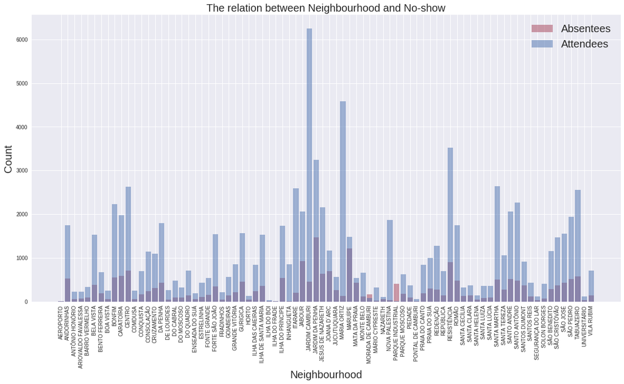

```python
Neighbourhood_Absentees = df_Absentees.groupby('Neighbourhood')['No-show'].count()
Neighbourhood_attendees = df_attendees.groupby('Neighbourhood')['No-show'].count()
print('\tAttendees')
print(Neighbourhood_attendees.sort_values(ascending=False))
print('-'*40)
print('\tAbsentees')
print(Neighbourhood_Absentees.sort_values(ascending=False))
plt.figure(figsize=(20, 10))
plt.bar(np.arange(len(Neighbourhood_Absentees)),
        Neighbourhood_Absentees, label='Absentees',color='#A54158',alpha=.5)
plt.bar(np.arange(len(Neighbourhood_attendees)), Neighbourhood_attendees,
        label='Attendees',alpha=.5)
plt.xticks(np.arange(len(Neighbourhood_Absentees)),
           Neighbourhood_attendees.index, rotation=90)
design('Neighbourhood','Count')
```

#### to make a clear comparison to find out the attendance and absence rate for each Neighbourhood let's divide each count by the total count for Absentees and Attendees to use proportions instead

```
----------------------------------------------------------------------------------------------------
	Attendees Proportion
Neighbourhood
PARQUE INDUSTRIAL              1.000000
ILHA DO BOI                    0.914286
AEROPORTO                      0.875000
MÁRIO CYPRESTE                 0.854447
SOLON BORGES                   0.852878
DE LOURDES                     0.845902
DO CABRAL                      0.842857
SANTA MARTHA                   0.841584
JARDIM DA PENHA                0.837245
DO QUADRO                      0.835100
VILA RUBIM                     0.834313
MORADA DE CAMBURI              0.833333
MATA DA PRAIA                  0.829193
REPÚBLICA                      0.828743
CONSOLAÇÃO                     0.828364
PONTAL DE CAMBURI              0.826087
SANTO ANTÔNIO                  0.824344
REDENÇÃO                       0.822923
NOVA PALESTINA                 0.822438
JABOUR                         0.820247
SANTA LUÍZA                    0.820093
COMDUSA                        0.819355
JOANA D´ARC                    0.819201
TABUAZEIRO                     0.817311
FORTE SÃO JOÃO                 0.816834
PRAIA DO CANTO                 0.816425
ANTÔNIO HONÓRIO                0.815498
BOA VISTA                      0.814103
FRADINHOS                      0.813953
CONQUISTA                      0.811543
                                 ...
SANTA HELENA                   0.792135
MARIA ORTIZ                    0.790009
SÃO PEDRO                      0.789624
UNIVERSITÁRIO                  0.789474
CENTRO                         0.789142
ROMÃO                          0.785908
```

[output cut: 75 more lines]

```
PARQUE MOSCOSO                 0.223192
BENTO FERREIRA                 0.224942
GURIGICA                       0.225966
PRAIA DO SUÁ                   0.228261
ANDORINHAS                     0.230327
CARATOÍRA                      0.230409
ILHA DO PRÍNCIPE               0.234775
HORTO                          0.240000
JESUS DE NAZARETH              0.243954
ITARARÉ                        0.262664
SANTA CLARA                    0.264822
SANTA CECÍLIA                  0.274554
SANTOS DUMONT                  0.289185
ILHAS OCEÂNICAS DE TRINDADE    1.000000
Name: No-show, Length: 81, dtype: float64
```

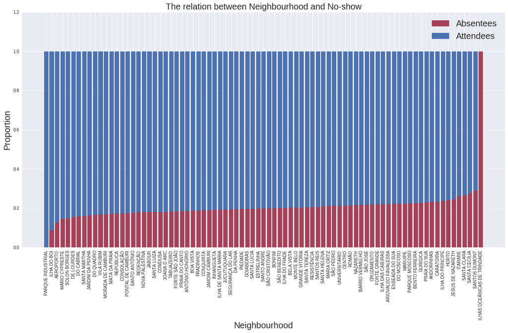

```python
total_Neighbourhood = df.groupby('Neighbourhood')['No-show'].count()
total_Neighbourhood = df.groupby('Neighbourhood')['No-show'].count()
p_Absentees_Neighbourhood = ((Neighbourhood_Absentees/total_Neighbourhood)
                      ).fillna(0).sort_values(ascending=True)
p_attendees_Neighbourhood = ((Neighbourhood_attendees/total_Neighbourhood)
                      ).fillna(0).sort_values(ascending=False)
print('-'*100)
print('\tAttendees Proportion')
print(p_attendees_Neighbourhood)
print('-'*40)
print('\tAbsentees Proportion')
print(p_Absentees_Neighbourhood)
plt.figure(figsize=(20, 10))
plt.bar(np.arange(len(p_Absentees_Neighbourhood)),
        p_Absentees_Neighbourhood, label='Absentees',color='#A54158')
plt.bar(np.arange(len(p_attendees_Neighbourhood)), p_attendees_Neighbourhood,
        label='Attendees', bottom=p_Absentees_Neighbourhood)
plt.xticks(np.arange(len(total_Neighbourhood)),
           p_attendees_Neighbourhood.index, rotation=90)
plt.ylim(0, 1.2)
design('Neighbourhood','Proportion')
```

### Is there a relationship between No-show and whether patient is enrolled in Brasilian welfare program Bolsa Família?

```
	Attendees
Scholarship
0    79924
1     8283
Name: No-show, dtype: int64
----------------------------------------
	Absentees
Scholarship
0    19736
1     2578
Name: No-show, dtype: int64
```

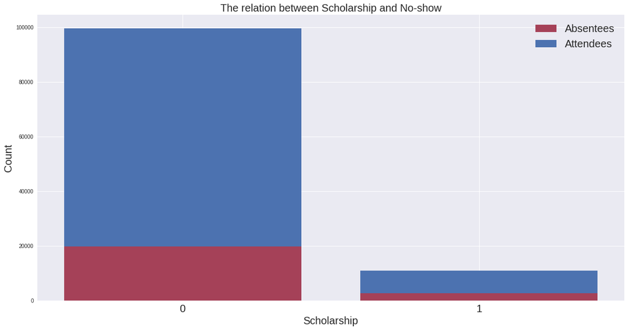

```python
Scholarship_Absentees = df_Absentees.groupby('Scholarship')['No-show'].count()
Scholarship_attendees = df_attendees.groupby('Scholarship')['No-show'].count()
print('\tAttendees')
print(Scholarship_attendees)
print('-'*40)
print('\tAbsentees')
print(Scholarship_Absentees)
plt.figure(figsize=(20, 10))
plt.bar(np.arange(len(Scholarship_Absentees)),
        Scholarship_Absentees, label='Absentees',color='#A54158')
plt.bar(np.arange(len(Scholarship_attendees)), Scholarship_attendees,
        label='Attendees', bottom=Scholarship_Absentees)
plt.xticks(np.arange(len(Scholarship_Absentees)),
           Scholarship_attendees.index, rotation=0, fontsize=20)
design('Scholarship','Count')
```

#### to make a clear comparsion to find out the attendance and absence rate whether enrolled or not let's divide each count by the total count for Absentees and Attendees to use proportions instead

```
----------------------------------------------------------------------------------------------------
	Attendees Proportion
Scholarship
0    0.801967
1    0.762637
Name: No-show, dtype: float64
----------------------------------------
	Absentees Proportion
Scholarship
0    0.198033
1    0.237363
Name: No-show, dtype: float64
```

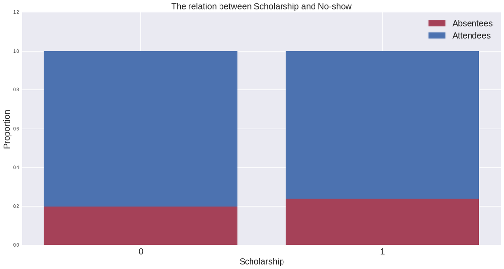

```python
total_Scholarship = df.groupby('Scholarship')['No-show'].count()
p_Absentees_Scholarship = ((Scholarship_Absentees/total_Scholarship)
                      ).fillna(0).sort_values(ascending=True)
p_attendees_Scholarship = ((Scholarship_attendees/total_Scholarship)
                      ).fillna(0).sort_values(ascending=False)
print('-'*100)
print('\tAttendees Proportion')
print(p_attendees_Scholarship)
print('-'*40)
print('\tAbsentees Proportion')
print(p_Absentees_Scholarship)
plt.figure(figsize=(20, 10))
plt.bar(np.arange(len(p_Absentees_Scholarship)),
        p_Absentees_Scholarship, label='Absentees',color='#A54158')
plt.bar(np.arange(len(p_attendees_Scholarship)), p_attendees_Scholarship,
        label='Attendees', bottom=p_Absentees_Scholarship)
plt.xticks(np.arange(len(total_Scholarship)),
           p_attendees_Scholarship.index, rotation=0, fontsize=20)
plt.ylim(0, 1.2)
design('Scholarship','Proportion')
```

### Is there a relationship between No-show and whether the patient has Hypertension?

```python
df['Hypertension'].value_counts().sort_values(ascending=False)
```

```
0    88720
1    21801
Name: Hypertension, dtype: int64
```

```
	Attendees
Hypertension
0    70178
1    18029
Name: No-show, dtype: int64
----------------------------------------
	Absentees
Hypertension
0    18542
1     3772
Name: No-show, dtype: int64
```

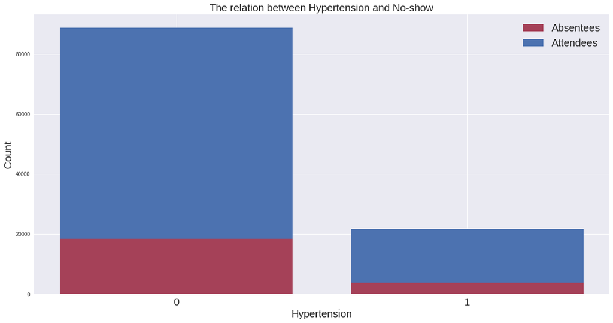

```python
Hypertension_Absentees = df_Absentees.groupby('Hypertension')['No-show'].count()
Hypertension_attendees = df_attendees.groupby('Hypertension')['No-show'].count()
print('\tAttendees')
print(Hypertension_attendees)
print('-'*40)
print('\tAbsentees')
print(Hypertension_Absentees)
plt.figure(figsize=(20, 10))
plt.bar(np.arange(len(Hypertension_Absentees)),
        Hypertension_Absentees, label='Absentees',color='#A54158')
plt.bar(np.arange(len(Hypertension_attendees)), Hypertension_attendees,
        label='Attendees', bottom=Hypertension_Absentees)
plt.xticks(np.arange(len(Hypertension_Absentees)),
           Hypertension_attendees.index, rotation=0, fontsize=20)
design('Hypertension','Count')
```

#### to make a clear comparsion to find out the attendance and absence rate whether has Hypertension or not let's divide each count by the total count for Absentees and Attendees to use proportions instead

```
----------------------------------------------------------------------------------------------------
	Attendees Proportion
Hypertension
1    0.826980
0    0.791005
Name: No-show, dtype: float64
----------------------------------------
	Absentees Proportion
Hypertension
1    0.173020
0    0.208995
Name: No-show, dtype: float64
```

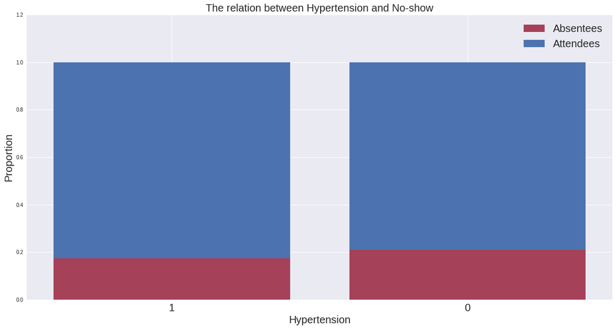

```python
total_Hypertension = df.groupby('Hypertension')['No-show'].count()
p_Absentees_Hypertension = ((Hypertension_Absentees/total_Hypertension)
                      ).fillna(0).sort_values(ascending=True)
p_attendees_Hypertension = ((Hypertension_attendees/total_Hypertension)
                      ).fillna(0).sort_values(ascending=False)
print('-'*100)
print('\tAttendees Proportion')
print(p_attendees_Hypertension)
print('-'*40)
print('\tAbsentees Proportion')
print(p_Absentees_Hypertension)
plt.figure(figsize=(20, 10))
plt.bar(np.arange(len(p_Absentees_Hypertension)),
        p_Absentees_Hypertension, label='Absentees',color='#A54158')
plt.bar(np.arange(len(p_attendees_Hypertension)), p_attendees_Hypertension,
        label='Attendees', bottom=p_Absentees_Hypertension)
plt.xticks(np.arange(len(total_Hypertension)),
           p_attendees_Hypertension.index, rotation=0, fontsize=20)
plt.ylim(0, 1.2)
design('Hypertension','Proportion')
```

Although the count having Hypertension is the least, but the No-show rate for patients having Hypertension or not is convergent, the Hypertension doesn't have any effect on it.

### Is there a relationship between No-show and whether the patient is Diabetic?

```python
df['Diabetes'].value_counts().sort_values(ascending=False)
```

```
0    102578
1      7943
Name: Diabetes, dtype: int64
```

```
	Attendees
Diabetes
0    81694
1     6513
Name: No-show, dtype: int64
----------------------------------------
	Absentees
Diabetes
0    20884
1     1430
Name: No-show, dtype: int64
```

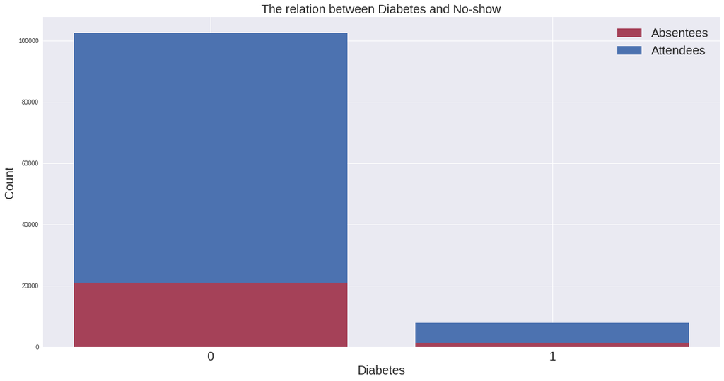

```python
Diabetes_Absentees = df_Absentees.groupby('Diabetes')['No-show'].count()
Diabetes_attendees = df_attendees.groupby('Diabetes')['No-show'].count()
print('\tAttendees')
print(Diabetes_attendees)
print('-'*40)
print('\tAbsentees')
print(Diabetes_Absentees)
plt.figure(figsize=(20, 10))
plt.bar(np.arange(len(Diabetes_Absentees)),
        Diabetes_Absentees, label='Absentees',color='#A54158')
plt.bar(np.arange(len(Diabetes_attendees)), Diabetes_attendees,
        label='Attendees', bottom=Diabetes_Absentees)
plt.xticks(np.arange(len(Diabetes_Absentees)),
           Diabetes_attendees.index, rotation=0, fontsize=20)
design('Diabetes','Count')
```

### to make a clear comparsion to find out the attendance and absence rate whether has Diabetes or not let's divide each count by the total count for Absentees and Attendees to use proportions instead

```
----------------------------------------------------------------------------------------------------
	Attendees Proportion
Diabetes
1    0.819967
0    0.796409
Name: No-show, dtype: float64
----------------------------------------
	Absentees Proportion
Diabetes
1    0.180033
0    0.203591
Name: No-show, dtype: float64
```

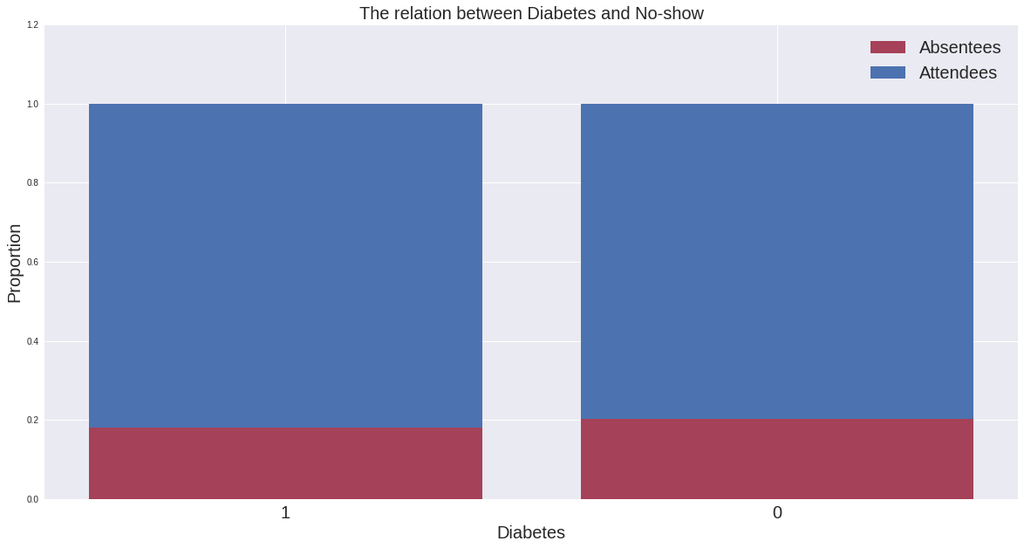

```python
total_Diabetes = df.groupby('Diabetes')['No-show'].count()
p_Absentees_Diabetes = ((Diabetes_Absentees/total_Diabetes)
                      ).fillna(0).sort_values(ascending=True)
p_attendees_Diabetes = ((Diabetes_attendees/total_Diabetes)
                      ).fillna(0).sort_values(ascending=False)
print('-'*100)
print('\tAttendees Proportion')
print(p_attendees_Diabetes)
print('-'*40)
print('\tAbsentees Proportion')
print(p_Absentees_Diabetes)
plt.figure(figsize=(20, 10))
plt.bar(np.arange(len(p_Absentees_Diabetes)),
        p_Absentees_Diabetes, label='Absentees',color='#A54158')
plt.bar(np.arange(len(p_attendees_Diabetes)), p_attendees_Diabetes,
        label='Attendees', bottom=p_Absentees_Diabetes)
plt.xticks(np.arange(len(total_Diabetes)),
           p_attendees_Diabetes.index, rotation=0, fontsize=20)
plt.ylim(0, 1.2)
design('Diabetes','Proportion')
```

Although the count having Diabetes is the least, but the No-show rate for patients having Diabetes or not is convergent, Diabetes doesn't have any effect on it.

### Is there a relationship between No-show and whether the patient has Alcoholism?

```python
df['Alcoholism'].value_counts().sort_values(ascending=False)
```

```
0    107161
1      3360
Name: Alcoholism, dtype: int64
```

```
	Attendees
Alcoholism
0    85524
1     2683
Name: No-show, dtype: int64
----------------------------------------
	Absentees
Alcoholism
0    21637
1      677
Name: No-show, dtype: int64
```

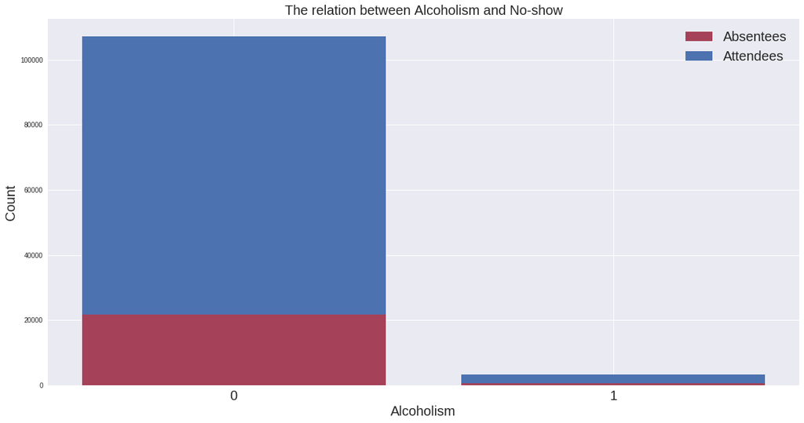

```python
Alcoholism_Absentees = df_Absentees.groupby('Alcoholism')['No-show'].count()
Alcoholism_attendees = df_attendees.groupby('Alcoholism')['No-show'].count()
print('\tAttendees')
print(Alcoholism_attendees)
print('-'*40)
print('\tAbsentees')
print(Alcoholism_Absentees)
plt.figure(figsize=(20, 10))
plt.bar(np.arange(len(Alcoholism_Absentees)),
        Alcoholism_Absentees, label='Absentees',color='#A54158')
plt.bar(np.arange(len(Alcoholism_attendees)), Alcoholism_attendees,
        label='Attendees', bottom=Alcoholism_Absentees)
plt.xticks(np.arange(len(Alcoholism_Absentees)),
           Alcoholism_attendees.index, rotation=0, fontsize=20)
design('Alcoholism','Count')
```

#### to make a clear comparsion to find out the attendance and absence rate whether has Alcoholism or not let's divide each count by the total count for Absentees and Attendees to use proportions instead

```
----------------------------------------------------------------------------------------------------
	Attendees Proportion
Alcoholism
1    0.798512
0    0.798089
Name: No-show, dtype: float64
----------------------------------------
	Absentees Proportion
Alcoholism
1    0.201488
0    0.201911
Name: No-show, dtype: float64
```

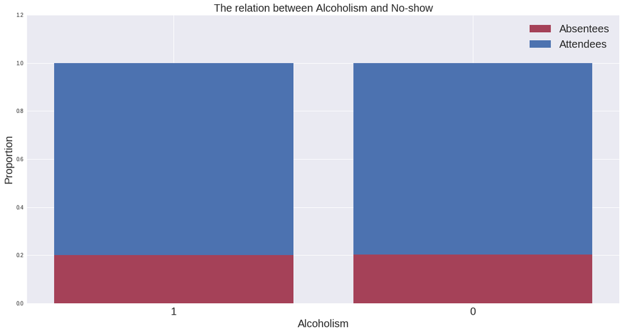

```python
total_Alcoholism = df.groupby('Alcoholism')['No-show'].count()
p_Absentees_Alcoholism = ((Alcoholism_Absentees/total_Alcoholism)
                      ).fillna(0).sort_values(ascending=True)
p_attendees_Alcoholism = ((Alcoholism_attendees/total_Alcoholism)
                      ).fillna(0).sort_values(ascending=False)
print('-'*100)
print('\tAttendees Proportion')
print(p_attendees_Alcoholism)
print('-'*40)
print('\tAbsentees Proportion')
print(p_Absentees_Alcoholism)
plt.figure(figsize=(20, 10))
plt.bar(np.arange(len(p_Absentees_Alcoholism)),
        p_Absentees_Alcoholism, label='Absentees',color='#A54158')
plt.bar(np.arange(len(p_attendees_Alcoholism)), p_attendees_Alcoholism,
        label='Attendees', bottom=p_Absentees_Alcoholism)
plt.xticks(np.arange(len(total_Alcoholism)),
           p_attendees_Alcoholism.index, rotation=0, fontsize=20)
plt.ylim(0, 1.2)
design('Alcoholism','Proportion')
```

Although the count having Alcoholism is the least, but the No-show rate for patients having Alcoholism or not is convergent, the Alcoholism doesn't have any effect on it.

### Is there a relationship between No-show and whether the patient has Handicap?

```python
df['Handicap'].value_counts().sort_values(ascending=False)
```

```
0    108282
1      2239
Name: Handicap, dtype: int64
```

```
	Attendees
Handicap
0    86373
1     1834
Name: No-show, dtype: int64
----------------------------------------
	Absentees
Handicap
0    21909
1      405
Name: No-show, dtype: int64
```

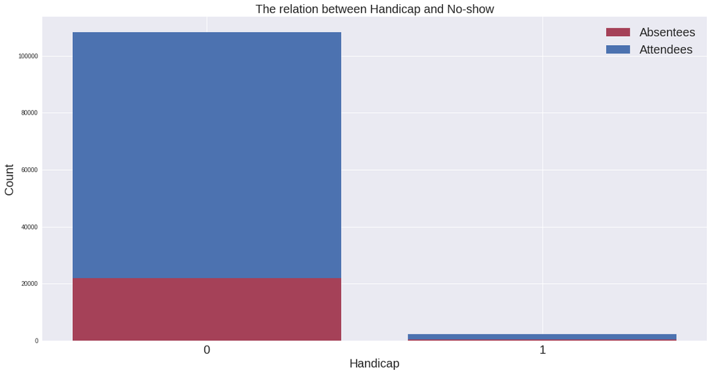

```python
Handicap_Absentees = df_Absentees.groupby('Handicap')['No-show'].count()
Handicap_attendees = df_attendees.groupby('Handicap')['No-show'].count()
print('\tAttendees')
print(Handicap_attendees)
print('-'*40)
print('\tAbsentees')
print(Handicap_Absentees)
plt.figure(figsize=(20, 10))
plt.bar(np.arange(len(Handicap_Absentees)),
        Handicap_Absentees, label='Absentees',color='#A54158')
plt.bar(np.arange(len(Handicap_attendees)), Handicap_attendees,
        label='Attendees', bottom=Handicap_Absentees)
plt.xticks(np.arange(len(Handicap_Absentees)),
           Handicap_attendees.index, rotation=0, fontsize=20)
design('Handicap','Count')
```

#### to make a clear comparsion to find out the attendance and absence rate whether has Handicap or not let's divide each count by the total count for Absentees and Attendees to use proportions instead

```
----------------------------------------------------------------------------------------------------
	Attendees Proportion
Handicap
1    0.819116
0    0.797667
Name: No-show, dtype: float64
----------------------------------------
	Absentees Proportion
Handicap
1    0.180884
0    0.202333
Name: No-show, dtype: float64
```

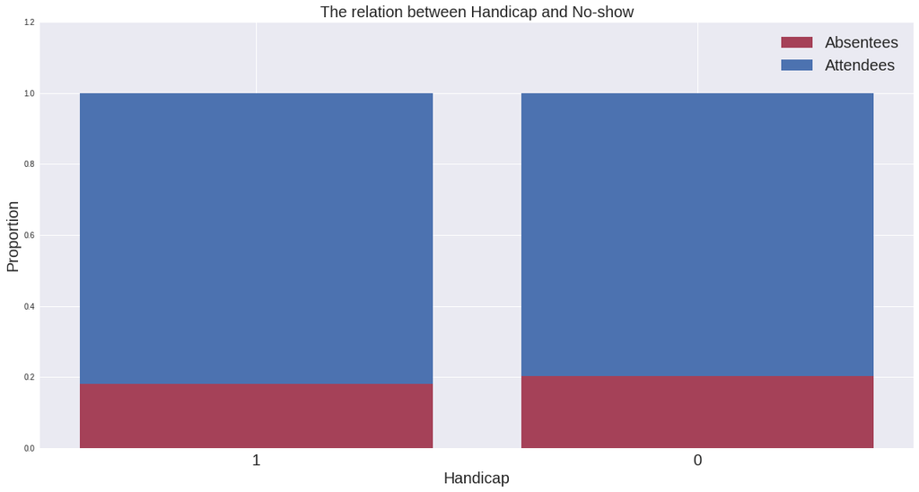

```python
total_Handicap = df.groupby('Handicap')['No-show'].count()
p_Absentees_Handicap = ((Handicap_Absentees/total_Handicap)
                      ).fillna(0).sort_values(ascending=True)
p_attendees_Handicap = ((Handicap_attendees/total_Handicap)
                      ).fillna(0).sort_values(ascending=False)
print('-'*100)
print('\tAttendees Proportion')
print(p_attendees_Handicap)
print('-'*40)
print('\tAbsentees Proportion')
print(p_Absentees_Handicap)
plt.figure(figsize=(20, 10))
plt.bar(np.arange(len(p_Absentees_Handicap)),
        p_Absentees_Handicap, label='Absentees',color='#A54158')
plt.bar(np.arange(len(p_attendees_Handicap)), p_attendees_Handicap,
        label='Attendees', bottom=p_Absentees_Handicap)
plt.xticks(np.arange(len(total_Handicap)),
           p_attendees_Handicap.index, rotation=0, fontsize=20)
plt.ylim(0, 1.2)
design('Handicap','Proportion')
```

Although the count having Handicap is the least, but the No-show rate for patients having Handicap or not is convergent, the Handicap doesn't have any effect on it.

### Is there a relationship between No-show and whether the patient received SMS?

```python
df['SMS_received'].value_counts().sort_values(ascending=False)
```

```
0    75039
1    35482
Name: SMS_received, dtype: int64
```

```
	Attendees
SMS_received
0    62509
1    25698
Name: No-show, dtype: int64
----------------------------------------
	Absentees
SMS_received
0    12530
1     9784
Name: No-show, dtype: int64
```

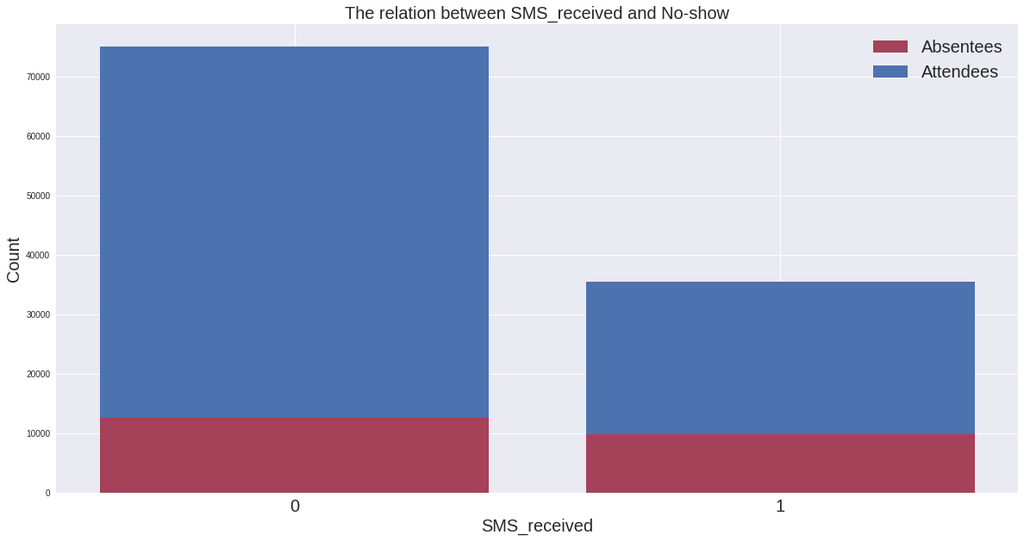

```python
SMS_received_Absentees = df_Absentees.groupby('SMS_received')['No-show'].count()
SMS_received_attendees = df_attendees.groupby('SMS_received')['No-show'].count()
print('\tAttendees')
print(SMS_received_attendees)
print('-'*40)
print('\tAbsentees')
print(SMS_received_Absentees)
plt.figure(figsize=(20, 10))
plt.bar(np.arange(len(SMS_received_Absentees)),
        SMS_received_Absentees, label='Absentees',color='#A54158')
plt.bar(np.arange(len(SMS_received_attendees)), SMS_received_attendees,
        label='Attendees', bottom=SMS_received_Absentees)
plt.xticks(np.arange(len(SMS_received_Absentees)),
           SMS_received_attendees.index, rotation=0, fontsize=20)
design('SMS_received','Count')
```

#### to make a clear comparsion to find out the attendance and absence rate whether has received SMS or not let's divide each count by the total count for Absentees and Attendees to use proportions instead

```
----------------------------------------------------------------------------------------------------
	Attendees Proportion
SMS_received
0    0.833020
1    0.724255
Name: No-show, dtype: float64
----------------------------------------
	Absentees Proportion
SMS_received
0    0.166980
1    0.275745
Name: No-show, dtype: float64
```

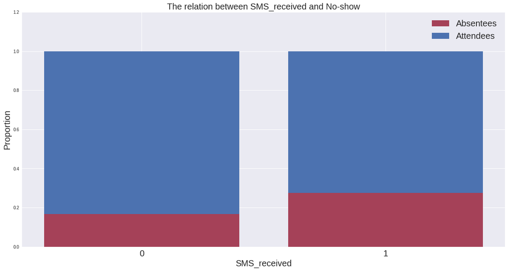

```python
total_SMS_received = df.groupby('SMS_received')['No-show'].count()
p_Absentees_SMS_received = ((SMS_received_Absentees/total_SMS_received)
                      ).fillna(0).sort_values(ascending=True)
p_attendees_SMS_received = ((SMS_received_attendees/total_SMS_received)
                      ).fillna(0).sort_values(ascending=False)
print('-'*100)
print('\tAttendees Proportion')
print(p_attendees_SMS_received)
print('-'*40)
print('\tAbsentees Proportion')
print(p_Absentees_SMS_received)
plt.figure(figsize=(20, 10))
plt.bar(np.arange(len(p_Absentees_SMS_received)),
        p_Absentees_SMS_received, label='Absentees',color='#A54158')
plt.bar(np.arange(len(p_attendees_SMS_received)), p_attendees_SMS_received,
        label='Attendees', bottom=p_Absentees_SMS_received)
plt.xticks(np.arange(len(total_SMS_received)),
           p_attendees_SMS_received.index, rotation=0, fontsize=20)
plt.ylim(0, 1.2)
design('SMS_received','Proportion')
```

### Is there a relationship between No-show and days of week?

```python
df['day_of_week'].value_counts().sort_values(ascending=False)
```

```
Wednesday    25866
Tuesday      25638
Monday       22713
Friday       19019
Thursday     17246
Saturday        39
Name: day_of_week, dtype: int64
```

```
	Attendees
day_of_week
Friday       14982
Monday       18024
Saturday        30
Thursday     13909
Tuesday      20488
Wednesday    20774
Name: No-show, dtype: int64
----------------------------------------
	Absentees
day_of_week
Friday       4037
Monday       4689
Saturday        9
Thursday     3337
Tuesday      5150
Wednesday    5092
Name: No-show, dtype: int64
```

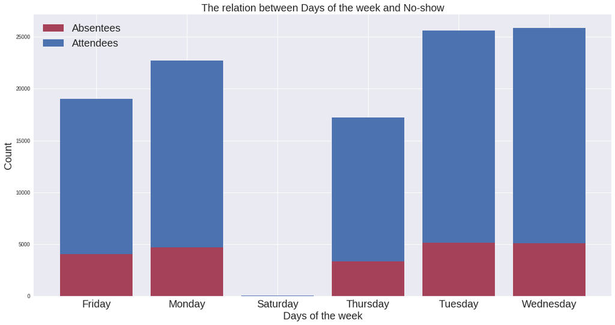

```python
day_of_week_Absentees = df_Absentees.groupby('day_of_week')['No-show'].count()
day_of_week_attendees = df_attendees.groupby('day_of_week')['No-show'].count()
print('\tAttendees')
print(day_of_week_attendees)
print('-'*40)
print('\tAbsentees')
print(day_of_week_Absentees)
plt.figure(figsize=(20, 10))
plt.bar(np.arange(len(day_of_week_Absentees)),
        day_of_week_Absentees, label='Absentees',color='#A54158')
plt.bar(np.arange(len(day_of_week_attendees)), day_of_week_attendees,
        label='Attendees', bottom=day_of_week_Absentees)
plt.xticks(np.arange(len(day_of_week_Absentees)),
           day_of_week_attendees.index, rotation=0, fontsize=20)
design('Days of the week','Count')
```

#### to make a clear comparsion to find out the attendance and absence rate for each day of week so let's divide each count by the total count for Absentees and Attendees to use proportions instead

```
----------------------------------------------------------------------------------------------------
	Attendees Proportion
day_of_week
Thursday     0.806506
Wednesday    0.803139
Tuesday      0.799126
Monday       0.793554
Friday       0.787739
Saturday     0.769231
Name: No-show, dtype: float64
----------------------------------------
	Absentees Proportion
day_of_week
Thursday     0.193494
Wednesday    0.196861
Tuesday      0.200874
Monday       0.206446
Friday       0.212261
Saturday     0.230769
Name: No-show, dtype: float64
```

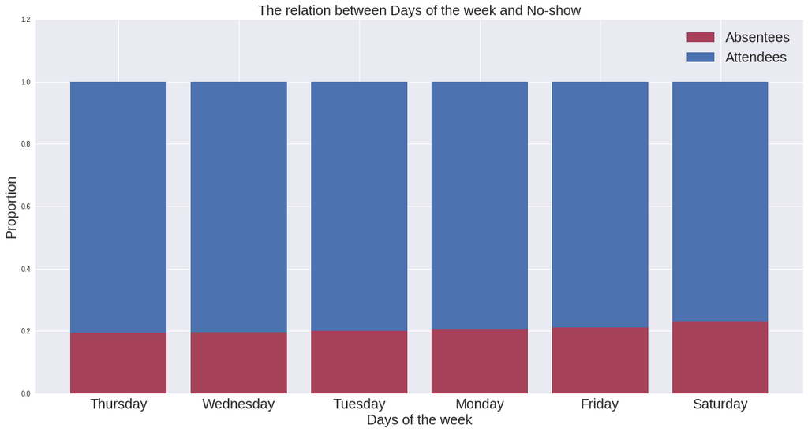

```python
total_day_of_week = df.groupby('day_of_week')['No-show'].count()
p_Absentees_day_of_week = ((day_of_week_Absentees/total_day_of_week)
                      ).fillna(0).sort_values(ascending=True)
p_attendees_day_of_week = ((day_of_week_attendees/total_day_of_week)
                      ).fillna(0).sort_values(ascending=False)
print('-'*100)
print('\tAttendees Proportion')
print(p_attendees_day_of_week)
print('-'*40)
print('\tAbsentees Proportion')
print(p_Absentees_day_of_week)
plt.figure(figsize=(20, 10))
plt.bar(np.arange(len(p_Absentees_day_of_week)),
        p_Absentees_day_of_week, label='Absentees',color='#A54158')
plt.bar(np.arange(len(p_attendees_day_of_week)), p_attendees_day_of_week,
        label='Attendees', bottom=p_Absentees_day_of_week)
plt.xticks(np.arange(len(total_day_of_week)),
           p_attendees_day_of_week.index, rotation=0, fontsize=20)
plt.ylim(0, 1.2)
design('Days of the week','Proportion')
```

the count of patients on Saturday is the least, but the No-show rate for patients every day of the week is convergent.

### Is there a relationship between No-show and the length of time between the day of booking and the day of the appointment?

```python
df['diff_period'].value_counts().sort_values(ascending=False)
```

```
the same day    38562
[16,179]        26246
[5,15]          25748
[1,4]           19965
Name: diff_period, dtype: int64
```

```
	Attendees
diff_period
the same day    36770
[1,4]           15375
[5,15]          18400
[16,179]        17662
Name: No-show, dtype: int64
----------------------------------------
	Absentees
diff_period
the same day    1792
[1,4]           4590
[5,15]          7348
[16,179]        8584
Name: No-show, dtype: int64
```

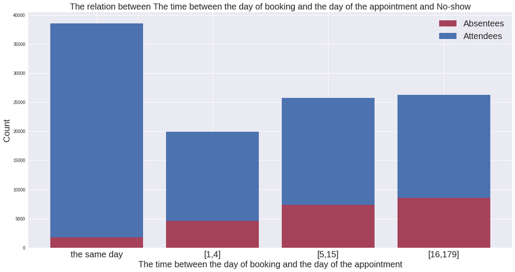

```python
diff_period_Absentees = df_Absentees.groupby('diff_period')['No-show'].count()
diff_period_attendees = df_attendees.groupby('diff_period')['No-show'].count()
print('\tAttendees')
print(diff_period_attendees)
print('-'*40)
print('\tAbsentees')
print(diff_period_Absentees)
plt.figure(figsize=(20, 10))
plt.bar(np.arange(len(diff_period_Absentees)),
        diff_period_Absentees, label='Absentees',color='#A54158')
plt.bar(np.arange(len(diff_period_attendees)), diff_period_attendees,
        label='Attendees', bottom=diff_period_Absentees)
plt.xticks(np.arange(len(diff_period_Absentees)),
           diff_period_attendees.index, rotation=0, fontsize=20)
design('The time between the day of booking and the day of the appointment','Count')
```

#### to make a clear comparsion to find out the attendance and absence rate for each period(the length of time between the day of booking and the day of the appointment) so let's divide each count by the total count for Absentees and Attendees to use proportions instead

```
----------------------------------------------------------------------------------------------------
	Attendees Proportion
diff_period
the same day    0.953529
[1,4]           0.770098
[5,15]          0.714619
[16,179]        0.672941
Name: No-show, dtype: float64
----------------------------------------
	Absentees Proportion
diff_period
the same day    0.046471
[1,4]           0.229902
[5,15]          0.285381
[16,179]        0.327059
Name: No-show, dtype: float64
```

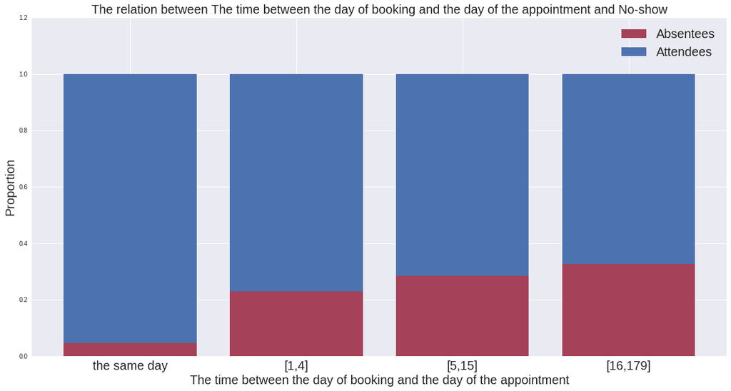

```python
total_diff_period = df.groupby('diff_period')['No-show'].count()
p_Absentees_diff_period = ((diff_period_Absentees/total_diff_period)
                      ).fillna(0).sort_values(ascending=True)
p_attendees_diff_period = ((diff_period_attendees/total_diff_period)
                      ).fillna(0).sort_values(ascending=False)
print('-'*100)
print('\tAttendees Proportion')
print(p_attendees_diff_period)
print('-'*40)
print('\tAbsentees Proportion')
print(p_Absentees_diff_period)
plt.figure(figsize=(20, 10))
plt.bar(np.arange(len(p_Absentees_diff_period)),
        p_Absentees_diff_period, label='Absentees',color='#A54158')
plt.bar(np.arange(len(p_attendees_diff_period)), p_attendees_diff_period,
        label='Attendees', bottom=p_Absentees_diff_period)
plt.xticks(np.arange(len(total_diff_period)),
           p_attendees_diff_period.index, rotation=0, fontsize=20)
plt.ylim(0, 1.2)
design('The time between the day of booking and the day of the appointment','Proportion')
```

the count patients booking in the same day is the biggest And the longer the time between the day of booking and the day of the appointment, The higher the No-show rate.

## Conclusions

-the attendance and absence rate for each gender is convergent, the gender doesn't have any effect on it.

-The No-show rate rises between 1 and 18 and reaches its highest level between 19 and 37, but it decreases between 38 and 55 to reach its lowest level between 56 and 115.

-there's a strong correlation between Neighbourhood and No-show.

-the No-show rate for enrolled patients or not enrolled patients is convergent, the Scholarship doesn't have any effect on it.

-Hypertension, Diabetes, Alcoholism, and Handicap don't have any effect on the No-show rate.

-the No-show rate for patients every day of the week is convergent.

-the count of patients booking on the same day is the biggest And the longer the time between the day of booking and the day of the appointment,The higher the No-show rate.

#### limitations:

```
-there's no clear correlation between No-show and gender, chronic diseases,enrollment in Scholarship.
-the column 'Handicap' should have only values 0 or 1 which mean false or trueand not contains the number  of Handicap [2,3,4] for each patient
```

```python
from subprocess import call
call(['python', '-m', 'nbconvert', 'Investigate_a_Dataset.ipynb'])
```

```
0
```